# HW2

Margarita Onvumere

2024-06-26

Let’s upload the data:

```r
data(Golub_Merge)
golub <- data.frame(Golub_Merge)[1:7129]
```

There are 47 patients with acute lymphoblastic leukemia (ALL) and 25 patients with acute myeloid leukemia (AML). The samples were assayed using Affymetrix Hgu6800 chips and data on the expression of 7129 genes (Affymetrix probes) are available.

Let’s check the distribution:

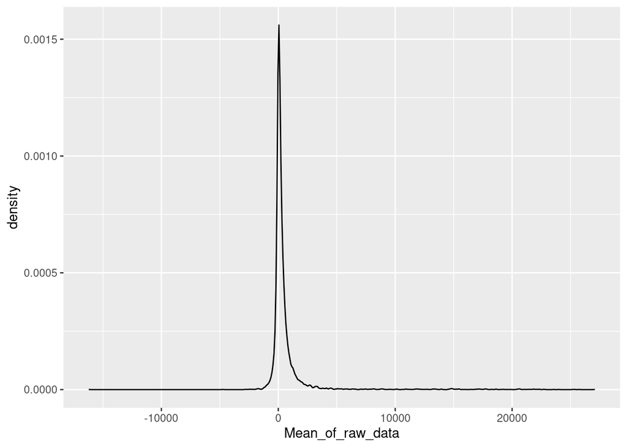

The distribution is good. According to golubEsets documentation, the dataset is already transformed, so we don’t have to normalise the data.

Let’s compare different distance matrix and clustering methods:

|  | method | ccc_value |
| --- | --- | --- |
| 12 | ward.D2 clustering, canberra distance | 0.3462864 |
| 6 | complete clustering, bray distance | 0.3608007 |
| 8 | ward.D2 clustering, bray distance | 0.4001858 |
| 16 | ward.D2 clustering, manhattan distance | 0.4317317 |
| 20 | ward.D2 clustering, gower distance | 0.4524317 |
| 14 | complete clustering, manhattan distance | 0.4667165 |
| 10 | complete clustering, canberra distance | 0.4699071 |
| 2 | complete clustering, euclidean distance | 0.4927641 |
| 4 | ward.D2 clustering, euclidean distance | 0.5093302 |
| 5 | single clustering, bray distance | 0.6768513 |

[output cut: 10 more lines]

The highest cophenetic correlation coefficient was achieved by using Gower distance and average clustering (UPGMA) methods.

Let’s now compare the clustering results with real data and for the best method:

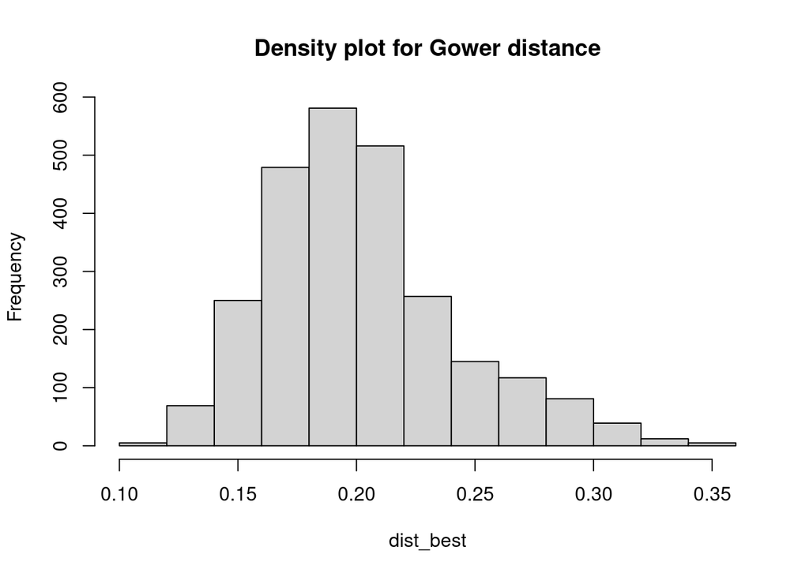

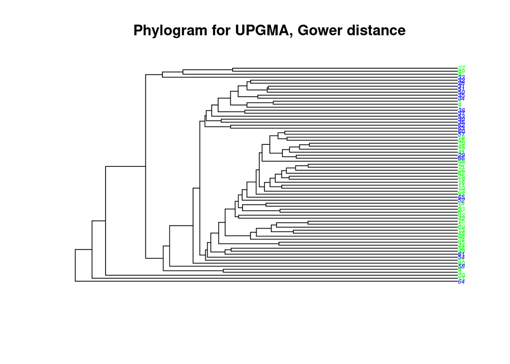

Additionally, since Gower distance is not available in pvclust, we will will make a comparison for model with Euclidean distance.

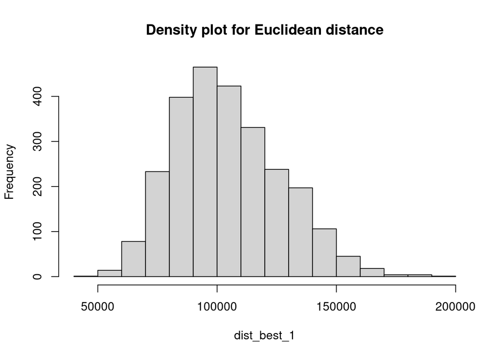

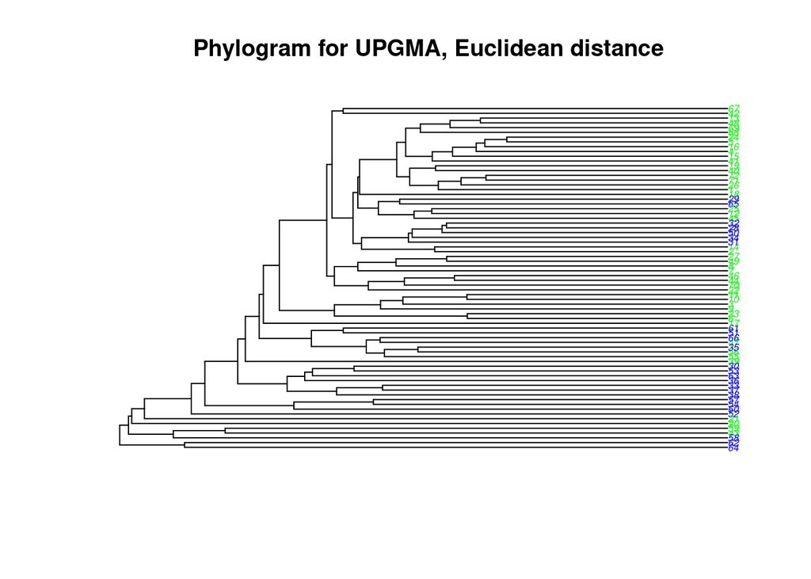

Bootstrap:

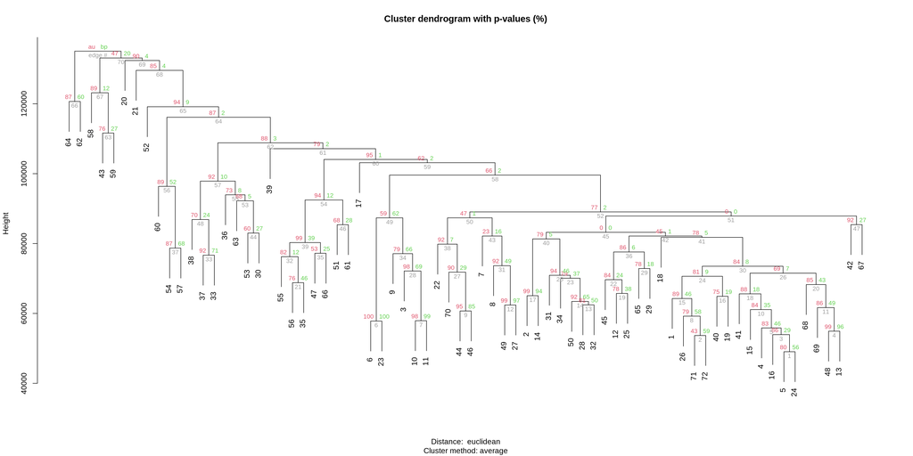

```r
# I ran this code in different environment (due to RAM limitations)
# cl_boot <- pvclust(t(golub), method.hclust = "average", nboot = 100, method.dist = "euclidean", parallel = TRUE, iseed = 42)
# options(repr.plot.width = 20, repr.plot.height =10, repr.plot.res = 200)
# plot(cl_boot)
```

**Conclusions**